# R Notebook

```r
# Load Packages
require(tidyterra)
require(dismo)
require(tidyverse)
require(terra)
require(predicts)
require(ggnewscale)
require(mgcv)
require(randomForest)
require(maxnet)
require(enmSdmX)
require(gbm)
require(patchwork)
#add any others needed
```

# Challenge 1 (4 points)

In the lab, we created 6 species distribution models (SDMs) for the same species using 6 different techniques. Plot the maps generated from (1) the bioclim envelope function, (2) the GLM model, and (3) the random forest model next to one another. What similarities and differences do you notice among these maps? What might explain some of these differences?

```r
# Loading the relevant data using the same code used in the lab

vathData = read.csv('https://raw.githubusercontent.com/ValenteJJ/SpatialEcology/main/Week8/vath_2004.csv')

vathPres = vathData %>% filter(VATH==1)
vathAbs = vathData %>% filter(VATH==0)

vathPresXy = as.matrix(vathPres %>% select(EASTING, NORTHING))
vathAbsXy = as.matrix(vathAbs %>% select(EASTING, NORTHING))


vathVal = read.csv('https://raw.githubusercontent.com/ValenteJJ/SpatialEcology/main/Week8/vath_VALIDATION.csv')

vathValPres = vathVal %>% filter(VATH==1)
vathValAbs = vathVal %>% filter(VATH==0)

vathValXy = as.matrix(vathVal %>% select(EASTING, NORTHING))
vathValPresXy = as.matrix(vathValPres %>% select(EASTING, NORTHING))
vathValAbsXy = as.matrix(vathValAbs %>% select(EASTING, NORTHING))

elev = rast('https://github.com/ValenteJJ/SpatialEcology/raw/main/Week8/elevation.tif')
canopy = rast('https://github.com/ValenteJJ/SpatialEcology/raw/main/Week8/canopy.tif')
mesic = rast('https://github.com/ValenteJJ/SpatialEcology/raw/main/Week8/mesic.tif')
precip = rast('https://github.com/ValenteJJ/SpatialEcology/raw/main/Week8/precip.tif')
crs(elev) = crs(mesic)
crs(canopy) = crs(mesic)

mesic = resample(x = mesic, y = elev, 'near')
precip = resample(x = precip, y = elev, 'bilinear')
mesic = mask(mesic, elev)
precip = mask(precip, elev)
compareGeom(elev, precip, canopy, mesic)
```

```
[1] TRUE
```

```r
probMatrix = focalMat(mesic, 1000, type='circle', fillNA=FALSE)
mesic1km = focal(mesic, probMatrix, fun='sum')

layers = c(canopy, elev, mesic, mesic1km, precip)
names(layers) = c('canopy', 'elev', 'mesic', 'mesic1km', 'precip')
layers = c(canopy, elev, mesic1km, precip)
names(layers) = c('canopy', 'elev', 'mesic1km', 'precip') # mesic was removed because of high correlation with mesic1km

set.seed(23)
backXy = data.frame(backgroundSample(layers, n=2000, p=vathPresXy))

presCovs = extract(layers, vathPresXy)
backCovs = extract(layers, backXy)
valCovs = extract(layers, vathValXy)

presCovs = data.frame(vathPresXy, presCovs, pres=1)
backCovs = data.frame(backXy, backCovs, pres=0)
valCovs = data.frame(vathValXy, valCovs)



presCovs = presCovs[complete.cases(presCovs),]
backCovs = backCovs[complete.cases(backCovs),]
valCovs = valCovs[complete.cases(valCovs),]


backCovs = backCovs %>% select(-ID)
colnames(presCovs)[1:2] = c('x', 'y')

presBackCovs = rbind(presCovs, backCovs)


tmp = presCovs %>% select(elev, precip, mesic1km, canopy) %>%
  as.matrix()

bioclim = envelope(tmp)
```

```
mtry = 2  OOB error = 4.15%
Searching left ...
mtry = 1    OOB error = 4.3%
-0.03448276 0.05
Searching right ...
mtry = 4    OOB error = 4.11%
0.01149425 0.05
      mtry   OOBError
1.OOB    1 0.04295943
2.OOB    2 0.04152745
4.OOB    4 0.04105012
```

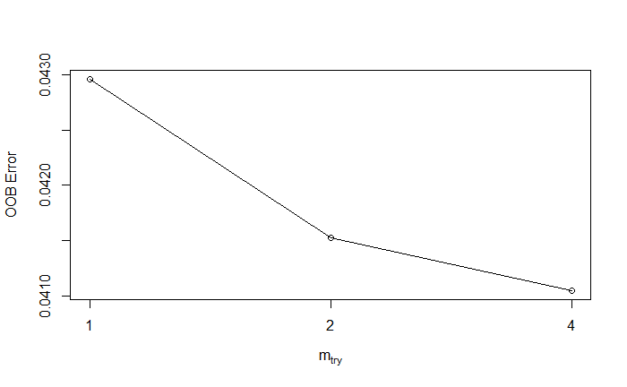

```r
# Set up bioclim envelope
bioclimMap = predict(layers, bioclim)

# Set up the GLM model
glmModel = glm(pres ~ canopy + elev + I(elev^2) + mesic1km + precip, family='binomial', data=presBackCovs)
glmMap = predict(layers, glmModel, type='response')

# Set up the random forest model
tuneRF(y = as.factor(presBackCovs$pres), x=presBackCovs[,3:6], stepFactor = 2, ntreeTry = 500)
```

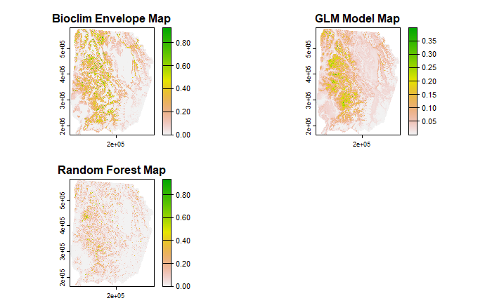

```r
rfModel = randomForest(as.factor(pres) ~ canopy + elev + mesic1km + precip, data=presBackCovs, mtry=2, ntree=500, na.action = na.omit)
rfMap = predict(layers, rfModel, type='prob', index=2)

# Plot all maps next to one another
layers2 = c(bioclimMap, glmMap, rfMap)
names(layers2) = c('Bioclim Envelope Map', 'GLM Model Map', 'Random Forest Map')
plot(layers2)
```

# Challenge 2 (4 points)

When we fit our GLM in lab, we used background points, rather than true absence points, to represent pseudo-absences. Fit the exact same GLM model, only this time use presence and true absence data. That is, replace the background rows in the dataframe with rows that represent actual sites where surveys were completed but Varied Thrush were not detected. Once you’ve fit the GLM, build a new SDM from this fitted model and visually compare the prediction surface to that built based on the presence-background model. What discrepancies do you notice, and what is your intuition regarding which of these two models is more reliable?

```r
absCovs = extract(layers, vathAbsXy)
absCovs = data.frame(vathAbsXy, absCovs, pres=0)
absCovs = absCovs[complete.cases(absCovs),]



colnames(absCovs)[1:2] = c('x', 'y')
```

```r
presAbsCovs = rbind(presCovs, absCovs)

glmModelAbs = glm(pres ~ canopy + elev + I(elev^2) + mesic1km + precip, family='binomial', data=presAbsCovs)

summary(glmModelAbs)
```

```
Call:
glm(formula = pres ~ canopy + elev + I(elev^2) + mesic1km + precip,
    family = "binomial", data = presAbsCovs)

Coefficients:
              Estimate Std. Error z value Pr(>|z|)
(Intercept) -11.530249   2.011445  -5.732 9.91e-09 ***
canopy        0.688663   0.314468   2.190  0.02853 *
elev          9.640661   3.039117   3.172  0.00151 **
I(elev^2)    -3.593218   1.164725  -3.085  0.00204 **
mesic1km      1.180551   0.399699   2.954  0.00314 **
precip        0.027727   0.005155   5.378 7.52e-08 ***
---
Signif. codes:  0 ‘***’ 0.001 ‘**’ 0.01 ‘*’ 0.05 ‘.’ 0.1 ‘ ’ 1

(Dispersion parameter for binomial family taken to be 1)

    Null deviance: 581.81  on 794  degrees of freedom
Residual deviance: 486.90  on 789  degrees of freedom
AIC: 498.9

Number of Fisher Scoring iterations: 6
```

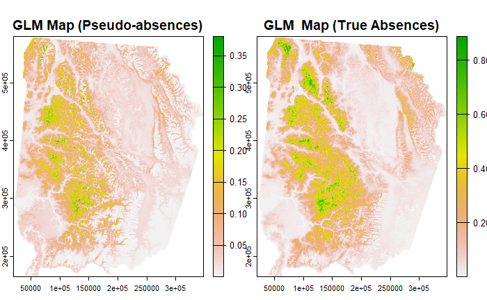

```r
glmMapAbs = predict(layers, glmModelAbs, type='response')

layers3 = c(glmMap, glmMapAbs)
names(layers3) = c('GLM Map (Pseudo-absences)', 'GLM  Map (True Absences)')
plot(layers3)
```

**ANSWER:** More absences in original (2000 simulated absences v 700 true absences) drives lower overall suitability. However, distribution of true absences (and presences) are likely to be biased due to accessibility of various sampling sites. Let’s visualize that.

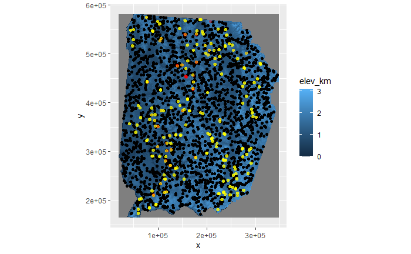

```r
ggplot() +
  geom_raster(data=elev, aes(x=x, y=y, fill=elev_km)) +
  geom_point(data=backXy, aes(x=x, y=y)) +
  geom_point(data=vathPres, aes(x=EASTING, y=NORTHING), color='red', alpha=0.3) +
  geom_point(data=vathAbs, aes(x=EASTING, y=NORTHING), color = 'yellow', alpha=0.3)+
  coord_fixed()
```